# Graphs in Python: Histograms *without using axes objects*

⇦ Back

**Histograms** are used to represent *continuous data*. This is in contrast to **bar plots** which represent *categorical data:*

> Bar plots have *categories* while histograms have *bins*

Conceptually, a histogram is like a combination of a line plot and a bar plot: data that could be shown as a continuous line is being grouped into bars. Here’s an example that is derived from one shown on [the Matplotlib website](https://matplotlib.org/stable/gallery/pyplots/pyplot_text.html) itself that illustrates this link between a line plot, a bar plot and a histogram:

# 1 Example Data

An intelligence quotient (IQ) test is an assessment where, by design, peoples’ results follow a normal distribution with a mean of 100 and a standard deviation of 15. The distribution of peoples’ scores will thus tend to a continuous line as the number of people tested tends to infinity (assuming that the tests are infinitely precise in their scoring), and so it can be represented on a graph as such. This type of graph is known as a probability density function (PDF) and a function to produce it is provided by Scipy’s “stats” package:

```python
from scipy.stats import norm
import numpy as np

# Create a normal distribution probability density function (PDF) with mean 100,
# standard deviation 15 and running from 45 to 155. It will consist of 1,000
# points to ensure it looks smooth when plotted.
x = np.linspace(45, 155, 1000)
mu, sigma = 100, 15
normal_pdf = norm.pdf(x, loc=mu, scale=sigma)
```

This can then be plotted with the Matplotlib package. The `plot()` function plots the x-data `x` against the y-data `normal_pdf` and, because there are 1,000 points being plotted, the resulting line looks smooth (although technically it is made up of 999 straight line segments). The `title()`, `xlabel()` and `ylabel()` functions then create the plot title and axis labels:

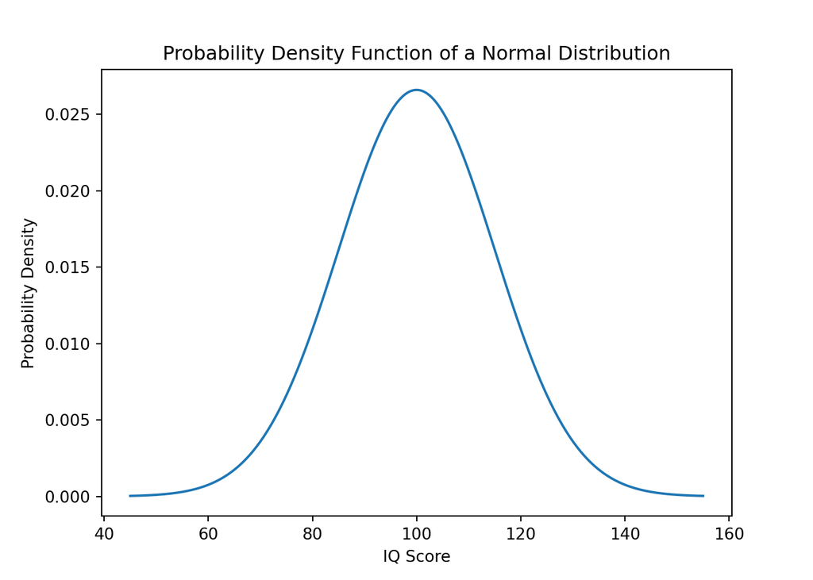

```python
import matplotlib.pyplot as plt

# Plot
plt.plot(x, normal_pdf)
plt.title('Probability Density Function of a Normal Distribution')
plt.ylabel('Probability Density')
plt.xlabel('IQ Score')
```

When we are given a finite sample of peoples’ scores, however, we can only approximate this distribution by putting the scores into ‘bins’, grouping scores of similar magnitudes together and representing those on a graph as vertical bars with height equal to the number of values in that bin.

For this example, we will generate 1,000 numbers by randomly taking values from a normal distribution of mean 100 and standard deviation 15. This will give us 1,000 hypothetical scores from IQ tests. Functions from the Numpy package will be used to do this:

```python
import numpy as np

# Set a seed for the random number generator so we get the same random numbers each time
np.random.seed(20210823)
# Randomly sample a normal distribution (of mean 100 and standard deviation 15) 1,000 times
mu, sigma = 100, 15
scores = np.random.normal(loc=mu, scale=sigma, size=1000)

# Print the first 10 scores just so we can see them
print(scores[:10])
```

```
## [103.33092853  83.89009815 125.79665832 134.92916125  92.25175415
##   92.92140271 112.5666037   97.18068497 106.82082533 116.67663664]
```

# 2 Plotting

Now we can use the `hist()` function from Matplotlib to group these 1,000 scores into bins and plot them. By default, it will create 10 bins of equal width:

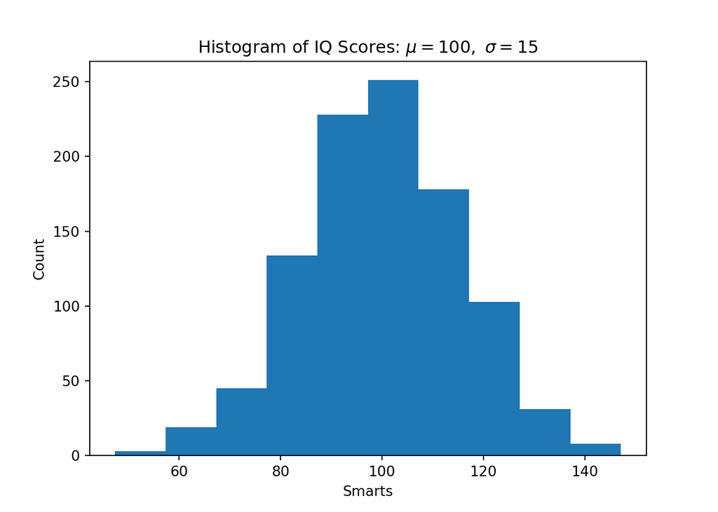

```python
import matplotlib.pyplot as plt

plt.hist(scores)
plt.title(r'Histogram of IQ Scores: $\mu=100,\ \sigma=15$')
plt.xlabel('Smarts')
plt.ylabel('Count')
```

Note the LaTeX formatting being used in the title; the `r` prepending the string causes it to be interpreted as a ‘raw string literal’ which is needed for this to work.

We can change the number of bins to make the histogram more or less precise by adding a second parameter to the `plt.hist()` function call (or by using its keyword: `bins`):

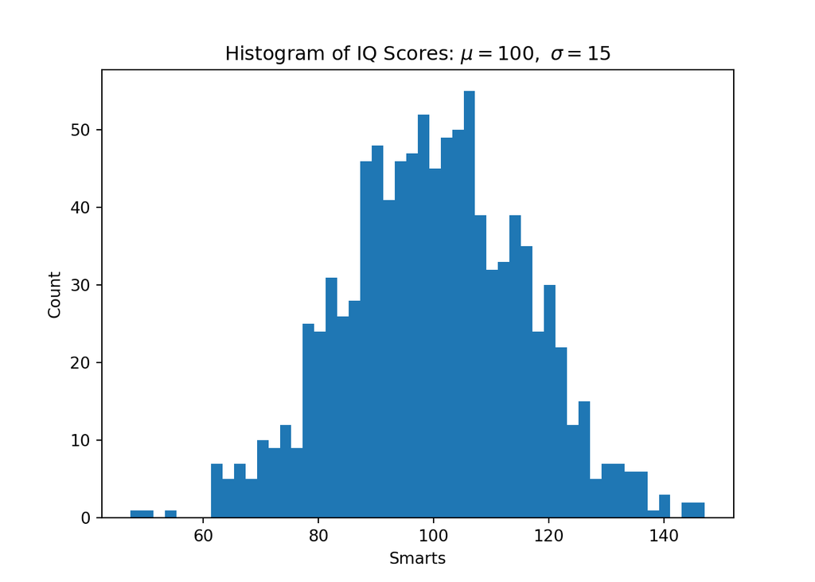

```python
# Create a histogram with 50 bins
plt.hist(scores, 50)
plt.title(r'Histogram of IQ Scores: $\mu=100,\ \sigma=15$')
plt.xlabel('Smarts')
plt.ylabel('Count')
```

Having *more* bins will make each one finer and will *increase* the precision while having *fewer* bins will make each one coarser and will *lower* the precision.

# 3 Normalising

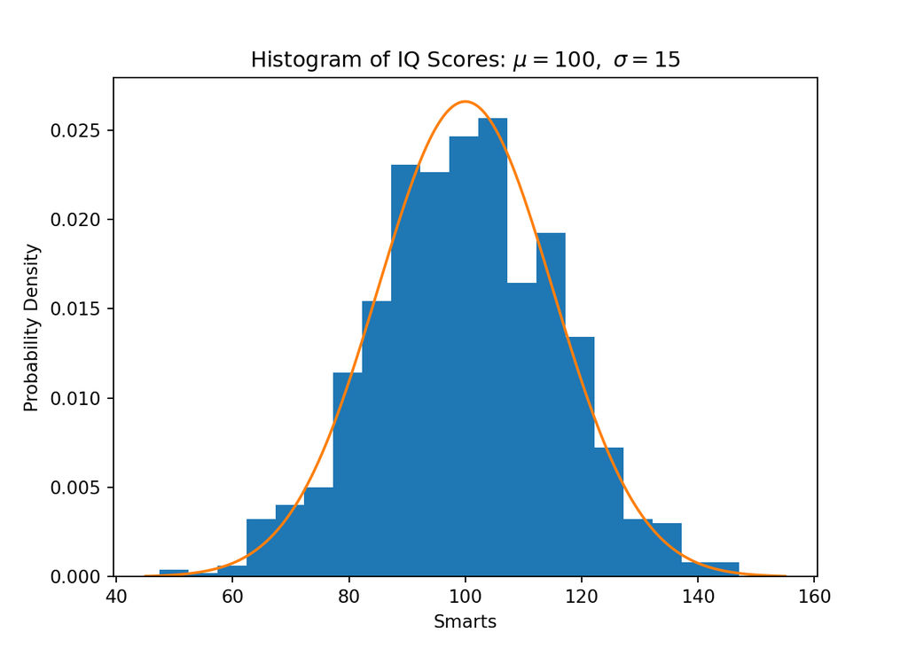

```python
plt.hist(scores, 20, density=True)
plt.plot(x, normal_pdf)
plt.title(r'Histogram of IQ Scores: $\mu=100,\ \sigma=15$')
plt.xlabel('Smarts')
plt.ylabel('Probability Density')
```

# 4 Additional Plot Features

The histogram can be customised by using its keyword arguments (see [here](https://matplotlib.org/stable/api/_as_gen/matplotlib.pyplot.hist.html) for the documentation on all the options):

- `histtype` changes the type of graph: bar plot, stacked bar plot, step plot or filled step plot
- The colour and thickness can be set with `edgecolor`, `facecolor` and `linewidth` (or their shorthands: `ec`, `fc` and `lw`)
- `label` sets the name that will be used in the legend
- `zorder` controls what elements in the plot are in front of others. A lower value for `zorder` means that it will be drawn first (ie it will be at the back, underneath other elements)

Other functions used below include:

- `axvline()` to create a **v**ertical **line** across the **ax**es
- `grid()` to add a grid
- `axis()` to manually control the size of the axes
- `legend()` to add a legend

The above functions can be customised using generic Matplotlib keyword arguments:

- `color` or `c` sets the colour (eg `'b'` for blue)
- `linestyle` or `ls` sets the line style (eg `'--'` for dashed)
- `alpha` sets the transparency
- `loc` sets the **loc**ation of the legend

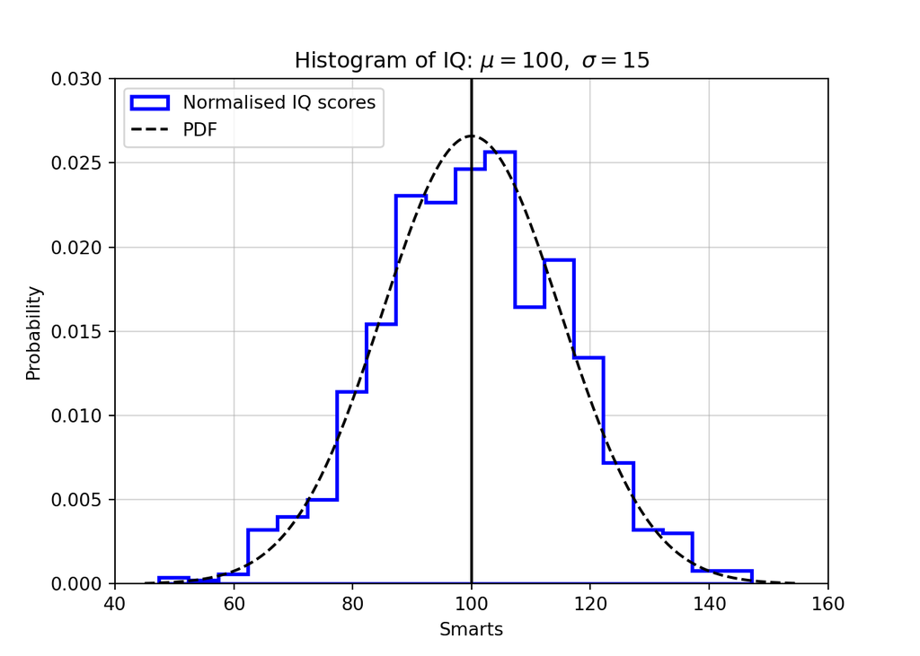

```python
# Normalised histogram
plt.hist(
    scores, 20, density=True,
    histtype='stepfilled',
    edgecolor='b', facecolor='w', linewidth=2,
    label='Normalised IQ scores',
    zorder=2
)
# Normal distribution
plt.plot(x, normal_pdf, c='k', ls='--', label='PDF')
# Midline
plt.axvline(mu, c='k')
# Add a grid
plt.grid(True, alpha=0.5, zorder=1)
# Titles and labels
plt.title(r'Histogram of IQ: $\mu=100,\ \sigma=15$')
plt.xlabel('Smarts')
plt.ylabel('Probability')
# Axis limits
plt.axis([40, 160, 0, 0.03])
# Add a legend
plt.legend(loc='upper left')
```

# 5 More LaTeX Formatting

While the headings of the above plots already use LaTeX’s math mode to get the Greek letters mu and sigma, additional LaTeX functionality (and more control of figures’ size and quality) can be unlocked by using the following code:

```python
# Make figures A5 in size
A = 5
plt.rc('figure', figsize=[46.82 * .5**(.5 * A), 33.11 * .5**(.5 * A)])
# Image quality
plt.rc('figure', dpi=141)
# Be able to add LaTeX
plt.rc('text', usetex=True)
plt.rc('font', family='serif')
plt.rc('text.latex', preamble=r'\usepackage{textgreek}')
```

The plot now looks like this:

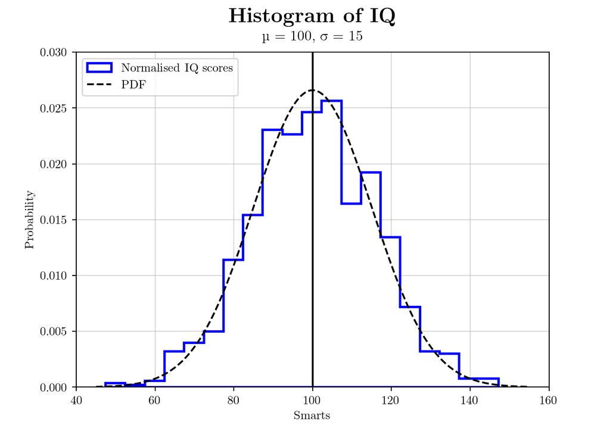

```python
# Normalised histogram
plt.hist(
    scores, 20, density=True,
    histtype='stepfilled',
    ec='b', fc='w', lw=2,
    label='Normalised IQ scores',
    zorder=2
)
# Normal distribution
plt.plot(x, normal_pdf, c='k', ls='--', label='PDF')
# Midline
plt.axvline(mu, c='k')
# Add a grid
plt.grid(True, alpha=0.5, zorder=1)
# Titles and labels
plt.title(
    r'\begin{center}{\bf\LARGE Histogram of IQ}\\\textmu\ = 100, \textsigma\ = 15\end{center}',
    pad=25
)
plt.xlabel('Smarts')
plt.ylabel('Probability')
# Axis limits
plt.axis([40, 160, 0, 0.03])
# Add a legend
plt.legend(loc='upper left')
```

⇦ Back